# TD 7

#### Objectif TD : Méthode des K plus proches voisins

On souhaite utiliser l’algorithme des K plus proches voisins sur différents jeux de données, à des fins de discrimination. On complétera tout d’abord les fonctions fournies, puis on les testera sur des données synthétiques (générées selon une distribution prédéfinie) puis réelles.

# Méthode des K plus proches voisins

On rappelle que la méthode des K plus proches voisins ne nécessite pas de phase d’apprentissage à proprement parler. On considérera les deux fonctions:

- **kppv.val** qui permet de calculer les classes f(x1), f(x2),…, f(xm) prédites pour chacun des m individus de test x1,x2,…,xm
- **kppv.tune** qui doit permettre de trouver la valeur de K donnant les meilleurs résultats sur un ensemble de données.

## 1. Implémentation

### Fonction kppv.val

Analyser la fonction kppv.val : comment fonctionne-t-elle ? Comment la sortie est-elle déterminée ? Quelle information pourrait-on retourner en plus du classement des individus de test ?

```r
kppv.val <- function(Xapp, zapp, K, Xtst)
{
    Xapp <- as.matrix(Xapp)
    Xtst <- as.matrix(Xtst)

    napp <- dim(Xapp)[1]
    ntst <- dim(Xtst)[1]
    p <- dim(Xapp)[2]

    # calcul des distances
    d2 <- distXY(Xtst, Xapp)
    d2sor <- t(apply(d2, 1, sort))

    # distance seuil pour chaque individu de l'ensemble
    # de test (distance a son Kieme plus proche voisin)
    seuil <- d2sor[,K]

    # identification des plus proches voisins
    is.ppv <- (d2<=matrix(rep(seuil,napp),nrow=ntst,byrow=F))

  # valeur de f pour les K plus proches voisins
  z.kppv <- matrix(rep(as.numeric(zapp),ntst),nrow=ntst,byrow=T)*is.ppv

  g <- nlevels(zapp)
  scores <- matrix(0,nrow=ntst,ncol=g)
  for (k in 1:g)
    {
        scores[,k] <- apply(z.kppv==k,1,sum)
  }

  # classement dans la classe majoritaire
  zpred <- as.factor(apply(scores, 1, which.max))
}
```

Calcul des distance à tous les points d’un ensemble de points de test, ordonnacement et selection des K plus proche voisins. Repérage de la classe majoritaire des plus proches voisins et classification. Renvoi vecteur des classes choisies.

### Fonction kppv.tune

Compléter la fonction kppv.tune, qui doit déterminer le nombre « optimal » de voisins Kopt (choisi parmi un vecteur nppv de valeurs possibles), c’est-à-dire donnant les meilleurs performances sur un ensemble de validation étiqueté (tableau individus-variables Xval de dimensions $nval * p$ ; et vecteur zval de sorties associées, de longueur nval).

La fonction prend donc en entrée :

- les données utilisées pour faire le classement : tableau individus-variables Xapp et vecteur zapp des étiquettes associées ;
- le tableau individus-variables Xval et le vecteur zval à utiliser pour la validation ;
- un ensemble de valeurs nppv correspondant aux différents nombres de voisins à tester.

Elle retourne la valeur Kopt choisie dans l’ensemble nppv et donnant les meilleurs résultats sur Xval.

```r
kppv.tune <- function(Xapp, zapp, Xval, zval, nppv)
{
    taux <- rep(0,length(nppv))
    for (k in nppv)
    {
      pred <- kppv.val(Xapp, as.factor(zapp), k, Xval)
      errRate <- 0
      for(i in length(zval)){
        if(pred[i]!=zval[i]){
          errRate = errRate + 1
        }
      }
    taux[k] <- errRate/length(zval)
    }
  Kopt <- which.min(taux)
  Kopt
}
```

## Sélection de modèle et évaluation des performances

Pour un jeu de données, on séparera aléatoirement l’ensemble des données disponibles, de manière à former un ensemble d’apprentissage et un ensemble de test (et éventuellement un ensemble de 1 validation si nécessaire). L’ensemble d’apprentissage est réservé à l’apprentissage du modèle uniquement (s’il y a lieu, on optimisera les hyper-paramètres sur l’ensemble de validation ou via une procédure spécifique) ; et l’ensemble de test n’est utilisé que pour l’estimation des performances.

*Remarque 1* : Dans certains cas, pour obtenir une estimation plus robuste des performances du modèle, on pourra répéter les étapes de séparation des données disponibles, apprentissage du modèle et estimation des performances (taux d’erreur de prédiction) par un taux d’erreur moyen ou médian. Il est parfois de coutume de calculer en plus un intervalle de confiance ou un diagramme en boîte à partir de ces données. Or, si la moyenne des taux d’erreur empiriques est un estimateur sans biais du taux d’erreur espéré du classifieur, ce n’est pas le cas de sa variance empirique (ou de la variance empirique corrigée) : les différents ensembles d’apprentissage (ou de test) obtenus par séparation des données ne sont pas distincts, un même individu pouvant être présent dans plusieurs ensembles. De ce fait, les taux d’erreur moyens calculés au cours de ces expériences répétées ne sont pas indépendants.

S’il est rigoureux d’utiliser leur moyenne pour estimer le risque, utiliser des intervalles de confiance ou des diagrammes en boîte pour comparer les performances de plusieurs modèles peut au contraire mener à des conclusions erronées, du fait du biais des estimations utilisées.

### Questions

#### Jeux de données synthétiques

##### 1. Pour chacun des jeux de données, estimer les paramètres $\mu_k$k et $\sum_k$ des distributions conditionnelles, ainsi que les proportions $\pi_k$ des classes.

```r
data40 <- read.csv("donnees/Synth1-40.csv", header = TRUE)
summary(data40)
unique(data40$z)
data40.cl1.prop <- dim(data40[data40$z == 1,])[1]/dim(data40)[1]
data40.cl2.prop <- 1 - data40.cl1.prop
data40.cl1.prop
data40.cl2.prop
cov(data40[1:2])

data100 <- read.csv("donnees/Synth1-100.csv")
summary(data100)
unique(data100$z)
data100.cl1.prop <- dim(data100[data100$z == 1,])[1]/dim(data100)[1]
data100.cl2.prop <- 1 - data100.cl1.prop
data100.cl1.prop
data100.cl2.prop
cov(data100[1:2])

data500 <- read.csv("donnees/Synth1-500.csv")
summary(data500)
unique(data500$z)
data500.cl1.prop <- dim(data500[data500$z == 1,])[1]/dim(data500)[1]
data500.cl2.prop <- 1 - data500.cl1.prop
data500.cl1.prop
data500.cl2.prop
cov(data500[1:2])

data1000 <- read.csv("donnees/Synth1-1000.csv")
summary(data1000)
unique(data1000$z)
data1000.cl1.prop <- dim(data1000[data1000$z == 1,])[1]/dim(data1000)[1]
data1000.cl2.prop <- 1 - data1000.cl1.prop
data1000.cl1.prop
data1000.cl2.prop
cov(data1000[1:2])
```

[output not shown]

##### 2. Effectuer une séparation aléatoire de l’ensemble de données en un ensemble d’apprentissage

et un ensemble de test (on pourra utiliser la fonction separ1). Déterminer le nombre optimal de voisins à l’aide de la fonction kppv.tune, en utilisant l’ensemble d’apprentissage comme ensemble de validation. Quel est le nombre optimal de voisins déterminé ? Pourquoi ?

```r
separ1 <- function(X, z)
{
    ntot <- dim(X)[1]

    iapp <- sample(1:ntot, round(2/3*ntot))
    itst <- setdiff(1:ntot, iapp)

    Xapp <- X[iapp,]
    zapp <- z[iapp]
    Xtst <- X[itst,]
    ztst <- z[itst]

    out <- NULL
    out$Xapp <- Xapp
    out$zapp <- zapp
    out$Xtst <- Xtst
    out$ztst <- ztst

    out
}
```

```r
front.kppv <- function(X, z, K, discretisation=50)
{
    deltaX <- (max(X[,1])-min(X[,1]))/discretisation
    deltaY <- (max(X[,2])-min(X[,2]))/discretisation
    minX <- min(X[,1])-deltaX
    maxX <- max(X[,1])+deltaX
    minY <- min(X[,2])-deltaY
    maxY <- max(X[,2])+deltaY

    # grille d'affichage
    grilleX <- seq(from=minX,to=maxX,by=deltaX)
    naffX <- length(grilleX)
    grilleY <- seq(from=minY,to=maxY,by=deltaY)
    naffY <- length(grilleY)
    grille <- cbind(rep.int(grilleX,times=rep(naffY,naffX)),rep(grilleY,naffX))

    # calcul des valeurs de la fonction
    valf <- kppv.val(X, z, K, grille)
    plot(X, col=c("red","green","blue","magenta","orange")[z], asp=1)
    contour(grilleX, grilleY, matrix(as.numeric(valf),nrow=naffX,byrow=T), add=T, drawlabels=FALSE, levels=1.5)
}
```

```r
data40sep <- separ1(data40[1:2],data40[,3])
Kopt40 <- kppv.tune(data40sep$Xapp, as.factor(data40sep$zapp), data40sep$Xapp, data40sep$zapp, seq(from=1,to=11,by=2))
Kopt40
```

```
[1] 1
```

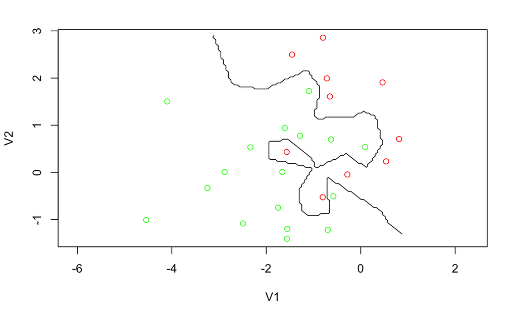

```r
front.kppv(data40sep$Xapp, as.factor(data40sep$zapp), Kopt40, 100)
```

```r
data100sep <- separ1(data100[1:2],data100[,3])
Kopt100 <- kppv.tune(data100sep$Xapp, as.factor(data100sep$zapp), data100sep$Xapp, data100sep$zapp, seq(from=1,to=11,by=2))
Kopt100
```

```
[1] 1
```

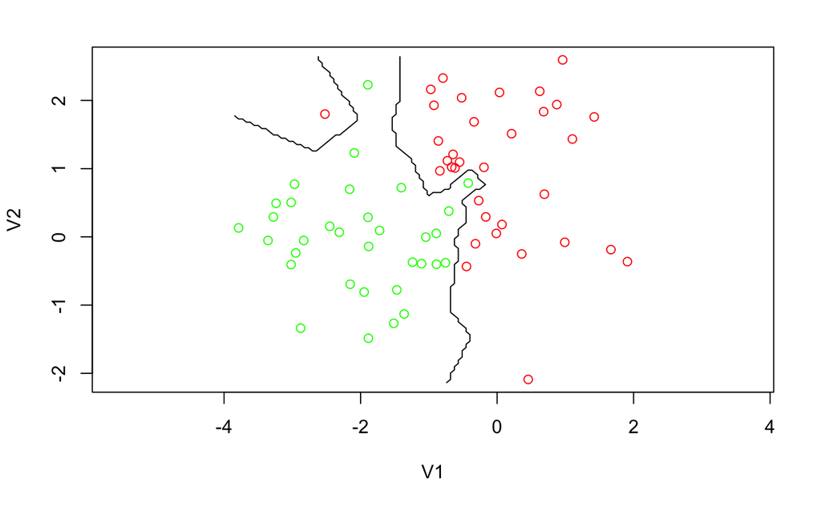

```r
front.kppv(data100sep$Xapp, as.factor(data100sep$zapp), Kopt100, 100)
```

```r
data500sep <- separ1(data500[1:2],data500[,3])
Kopt500 <- kppv.tune(data500sep$Xapp, as.factor(data500sep$zapp), data500sep$Xapp, data500sep$zapp, seq(from=1,to=11,by=2))
Kopt500
```

```
[1] 1
```

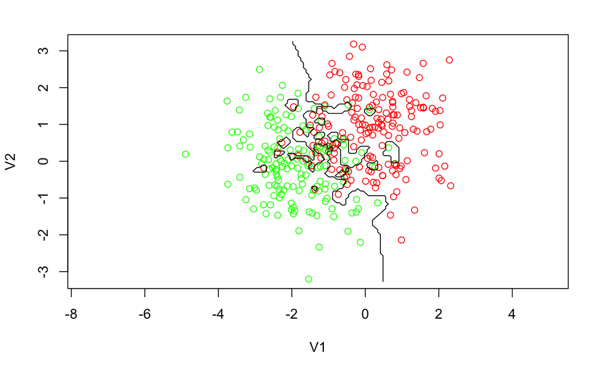

```r
front.kppv(data500sep$Xapp, as.factor(data500sep$zapp), Kopt500, 100)
```

```r
data1000sep <- separ1(data1000[1:2],data1000[,3])
Kopt1000 <- kppv.tune(data1000sep$Xapp, as.factor(data1000sep$zapp), data1000sep$Xapp, data1000sep$zapp, seq(from=1,to=11,by=2))
Kopt1000
```

```
[1] 1
```

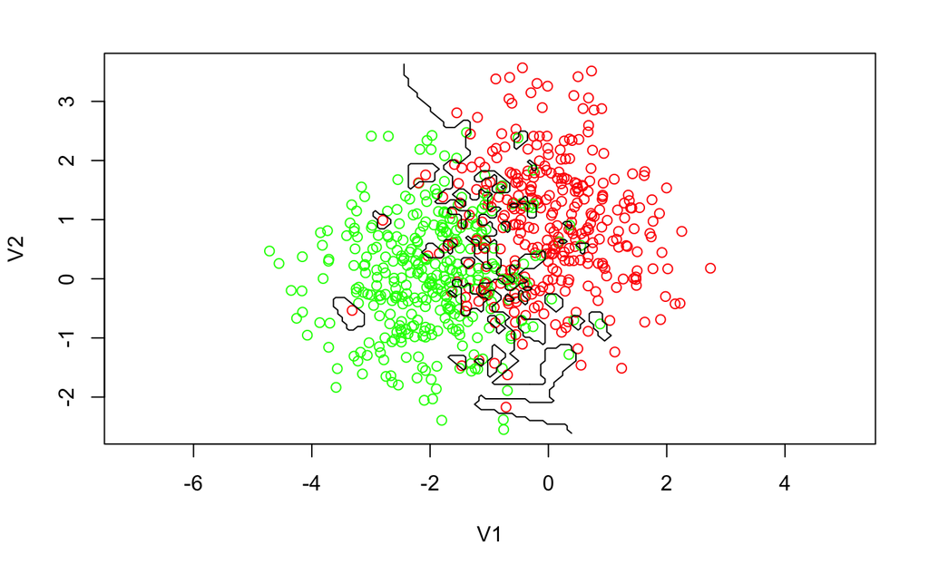

```r
front.kppv(data1000sep$Xapp, as.factor(data1000sep$zapp), Kopt1000, 100)
```

Si on utilise l’ensemble d’apprentissage comme ensemble de validation, le nombre optimal est forcément 1 –> sur-apprentissage.

##### 3. Écrire un script qui effectue N = 20 séparations aléatoires du jeu de données Synth1-1000 en

ensembles d’apprentissage, de validation, et de test (on pourra utiliser la fonction separ2) ; et qui, pour chacune :

- D’une part, détermine (et stocke) le nombre optimal de voisins Kopt ;
- D’autre part, calcule (et stocke) les taux d’erreur d’apprentissage, de validation et de test pour différentes valeurs de K (les mêmes que celles testées pour déterminer Kopt).

```r
separ2 <- function(X, z)
{
  ntot <- dim(X)[1]
  iapp <- sample(1:ntot, round(1/2*ntot))
  ival <- sample(setdiff(1:ntot,iapp), round(1/4*ntot))
  itst <- setdiff(1:ntot, c(iapp,ival))
  Xapp <- X[iapp,]
  zapp <- z[iapp]
  Xval <- X[ival,]
  zval <- z[ival]
  Xtst <- X[itst,]
  ztst <- z[itst]
  out <- NULL
  out$Xapp <- Xapp
  out$zapp <- zapp
  out$Xval <- Xval
  out$zval <- zval
  out$Xtst <- Xtst
  out$ztst <- ztst
  out
}
```

```r
KOPT <- rep(0, 20)
ERRAPPR <- rep(0, 20)
ERRVAL <- rep(0, 20)
ERRTEST <- rep(0, 20)
for (k in (1:20)){
  datasep <- separ2(data1000[,1:2],data1000[,3])
  KOPT[k] <- kppv.tune(datasep$Xapp, as.factor(datasep$zapp), datasep$Xval, datasep$zval, seq(from=1,to=20,by=1))

  pred <- kppv.val(datasep$Xapp, as.factor(datasep$zapp), KOPT[k], datasep$zval)
  errRate <- 0
  for(i in length(datasep$zapp)){
    if(pred[i]!=datasep$zapp[i]){
      errRate = errRate + 1
    }
  }
  ERRAPPR[k] <- errRate/length(datasep$zapp)

  pred2 <- kppv.val(datasep$Xapp, as.factor(datasep$zapp), KOPT[k], datasep$ztst)
  errRate2 <- 0
  for(i in length(datasep$zapp)){
    if(pred2[i]!=datasep$zapp[i]){
      errRate2 = errRate2 + 1
    }
  }
  ERRVAL[k] <- errRate2/length(datasep$ztst)
}
```

[output not shown]

Représenter les taux d’erreur d’apprentissage, de validation et de test. L’estimation du nombre optimal de voisins semble-t-elle stable ? Pourquoi ?

#### Jeux de données réelles

On considère maintenant les jeux de données Pima et Breastcancer. Traiter ces jeux de données suivant le protocole utilisés sur les données synthétiques. Calculer les estimations de $\epsilon$ sur l’ensemble d’apprentissage et sur l’ensemble de test. Commenter et interpréter les résultats obtenus.

## 2. Méthode des « K plus proches prototypes »

La méthode des K plus proches voisins présente des propriétés intéressantes, mais cette stratégie reste coûteuse : elle nécessite, en phase de test, de calculer la distance entre chaque individu de 2 test et tous les individus d’apprentissage. On souhaite ici en tester une variante, dans laquelle l’ensemble d’apprentissage sera résumé par un ensemble de points caractéristiques que nous appellerons prototypes. Le bénéfice attendu d’une telle opération est évidemment calculatoire ; notons qu’elle a également une influence sur le plan des performances, en fonction du nombre de prototypes choisi pour résumer une classe et de la manière dont ces prototypes sont déterminés.

### Apprentissage des prototypes

**Cette variante de la méthode des K plus proches voisins comporte à présent une phase d’apprentissage**

### Questions

Pour les jeux de données synthétiques, on pourra utiliser la fonction front.kppp pour afficher l’ensemble d’apprentissage, les prototypes obtenus et les frontières de décision associées.